# Stat 563 Project- Final

### Model Diagnostics for the Backward Model

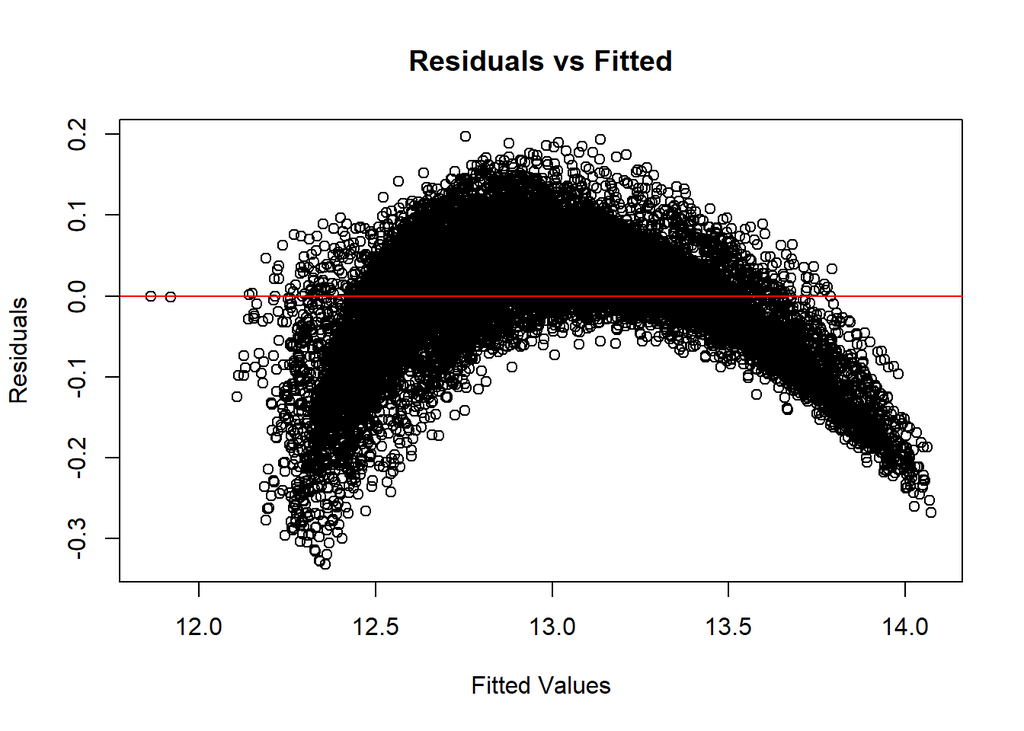

```r
 # Residuals vs Fitted
plot(resid(backward_model) ~ fitted(backward_model),
     main = "Residuals vs Fitted",
     xlab = "Fitted Values",
     ylab = "Residuals")
abline(h = 0, col = "red")
```

The Residuals vs Fitted plot shows a clear curved pattern, indicating non-linearity between predictors and the response variable.

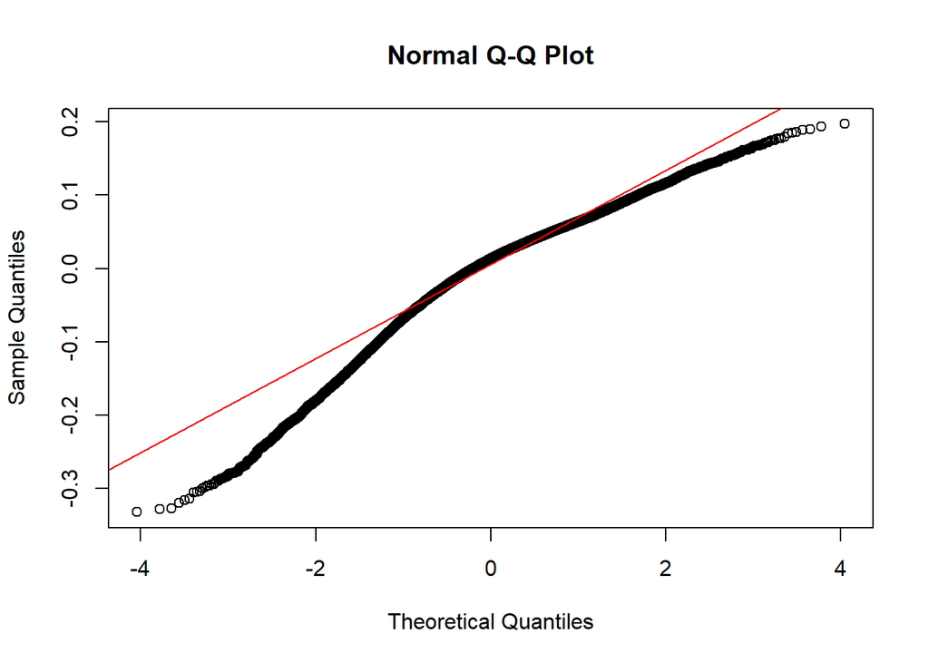

```r
# Q-Q Plot
qqnorm(resid(backward_model), main = "Normal Q-Q Plot")
qqline(resid(backward_model), col = "red")
```

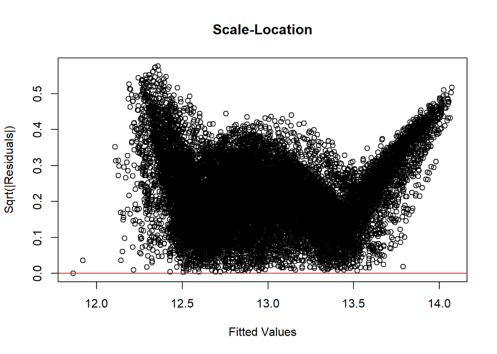

```r
# Scale-Location Plot
plot(sqrt(abs(resid(backward_model))) ~ fitted(backward_model),
     main = "Scale-Location",
     xlab = "Fitted Values",
     ylab = "Sqrt(|Residuals|)")
abline(h = 0, col = "red")
```

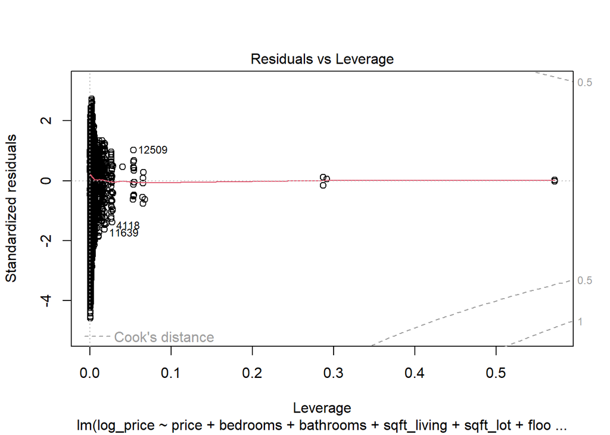

```r
# Residuals vs Leverage
plot(backward_model, which = 5) # Cook's Distance
```

After the diagnostics on our backward model, the predictors zipcode, yr_renovated, sqft_lot15, and month_sold were removed from the model as they showed minimal contributions to reducing the residual sum of squares (RSS) and had negligible impact on improving the model’s overall fit, as indicated by their low sum of squares in the backward elimination output. Additionally, these predictors had higher p-values, suggesting they were not statistically significant in explaining the variability in the response variable.

### Considering Refined Versions of the Backward Selection Model

```r
# Updating the backward model thus removing insignificant predictors
model_refined <- lm(log_price ~ grade + lat + sqft_living + yr_built +bedrooms+
                      sqft_living15 + floors + condition + view +
                      year_sold + bathrooms + waterfront, data = refined_data)
summary(model_refined)
```

#Interpretation:

The R-squared is 0.7125 indicating that 71.25% of the variability in the response variable (log_price) is explained by the predictors in the model. This is a strong result for a real-world model. The F-statistic (1880 on 25 and 18969 DF, p-value: < 2.2e-16) confirms that the overall model is statistically significant. The residual standard error (0.2192) is small indicating a good fit. The model balances the number of predictors and explanatory power well, as shown by the close R-squared(0.7125) and adjusted R-squared (0.7121).

```r
# Function to compute metrics for each model
compute_model_metrics <- function(model, data) {
  sse <- sum(residuals(model)^2)
  r2 <- summary(model)$r.squared
  adj_r2 <- summary(model)$adj.r.squared
  aic <- AIC(model)
  bic <- BIC(model)

  # Calculate Cp (Mallow's Cp)
  cp <- sse / (var(model$residuals) * (nrow(data) - length(coef(model)))) + 2 * length(coef(model)) - nrow(data)


  return(data.frame(SSE = sse, R2 = r2, Adj_R2 = adj_r2, AIC = aic, BIC = bic, Cp = cp))
}

# Compute metrics for all models
metrics_refined <- compute_model_metrics(model_refined, refined_data)

# Combine the results
results <- rbind(
  cbind(Model = "Refined", metrics_refined)
)

# Display the table
results
```

```
##     Model      SSE        R2    Adj_R2       AIC      BIC     Cp
## 1 Refined 911.0692 0.7124542 0.7120752 -3733.071 -3521.07 -18941
```

### Model Diagnostics for the Refined Backward Selection Model

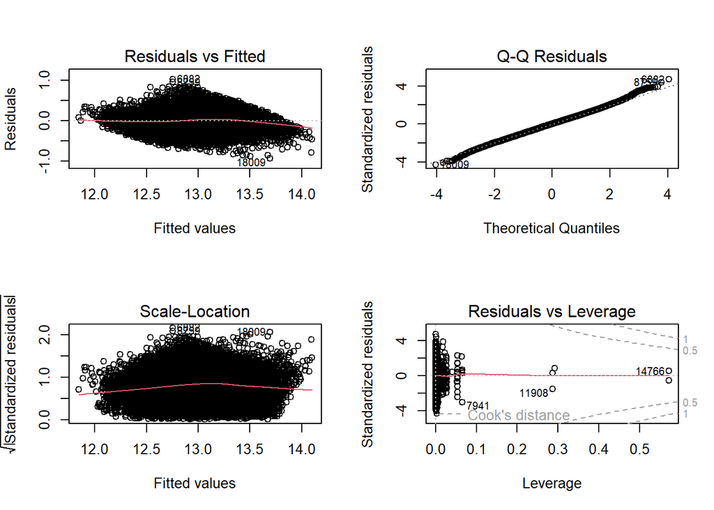

```r
# Plot diagnostic plots for model_refined
par(mfrow = c(2, 2))  # Set up a 2x2 grid for plots
plot(model_refined)
```

### Considering Interaction Terms

```r
# Fit models with interaction terms
model_1 <- lm(log_price ~ . + waterfront:condition, data = refined_data)
model_2 <- lm(log_price ~ . + waterfront:grade, data = refined_data)
model_3 <- lm(log_price ~ . + bathrooms:floors, data = refined_data)
model_4 <- lm(log_price ~ . + sqft_living:condition, data = refined_data)
model_5 <- lm(log_price~  . + condition:grade, data = refined_data)

# Compute metrics for each model
metrics_1 <- compute_model_metrics(model_1, refined_data)
metrics_2 <- compute_model_metrics(model_2, refined_data)
metrics_3 <- compute_model_metrics(model_3, refined_data)
metrics_4 <- compute_model_metrics(model_4, refined_data)
metrics_5 <- compute_model_metrics(model_5, refined_data)


# Combine metrics into a table
interaction_results <- rbind(
  cbind(Model = "Waterfront:Condition", metrics_1),
  cbind(Model = "Waterfront:Grade", metrics_2),
  cbind(Model = "Bathrooms:Floors", metrics_3),
  cbind(Model = "Sqft Living:Condition", metrics_4),
  cbind(Model = "Condition:Grade", metrics_5)

)

# Display the table
interaction_results
```

```
##                   Model      SSE        R2    Adj_R2       AIC       BIC     Cp
## 1  Waterfront:Condition 99.24308 0.9686775 0.9686230 -45827.66 -45552.84 -18919
## 2      Waterfront:Grade 99.24035 0.9686784 0.9686206 -45824.18 -45533.66 -18911
## 3      Bathrooms:Floors 98.95638 0.9687680 0.9687137 -45882.61 -45607.79 -18925
## 4 Sqft Living:Condition 99.05219 0.9687378 0.9686784 -45858.23 -45559.85 -18919
## 5       Condition:Grade 97.97284 0.9690784 0.9689985 -46040.33 -45639.89 -18863
```

### Interaction Term Analysis

We evaluated multiple interaction terms to identify the best-performing model based on key metrics such as $R^2$, Adjusted $R^2$, SSE, AIC, BIC, and Cp. The table below summarizes the results:

| Interaction Term | SSE | R² | Adjusted R² | AIC | BIC | Cp |
| --- | --- | --- | --- | --- | --- | --- |
| Waterfront:Condition | 99.24308 | 0.9686775 | 0.9686230 | -45827.66 | -45552.84 | -18919 |
| Waterfront:Grade | 99.24035 | 0.9686784 | 0.9686206 | -45824.18 | -45533.66 | -18911 |
| Bathrooms:Floors | 98.95638 | 0.9687680 | 0.9687137 | -45882.61 | -45607.79 | -18925 |
| Sqft Living:Condition | 99.05219 | 0.9687378 | 0.9686784 | -45858.23 | -45559.85 | -18919 |
| Condition:Grade | 97.97284 | 0.9690784 | 0.9689985 | -46040.33 | -45639.89 | -18863 |

### Diagnostics for Condition:Grade Interation Model

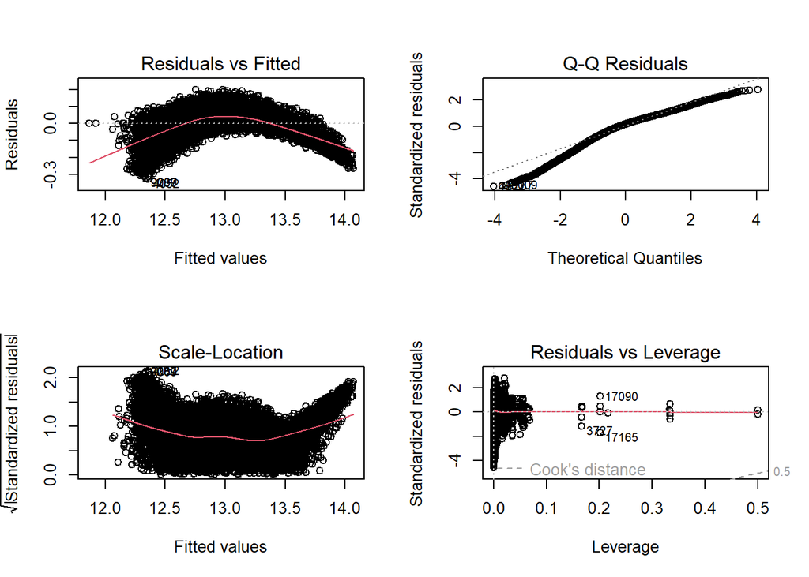

```r
# Graphical diagnostics
par(mfrow = c(2, 2))  # Layout for 4 plots
plot(model_5)  # Produces Residuals vs Fitted, Q-Q Plot, Scale-Location, and Residuals vs Leverage
```

## Diagnostic Plots for Model Assumptions

### Considering other Models and Evaluating Performance

We further considered the refined model by testing the exclusion of specific variables (`grade` and `condition`) to assess their impact on model performance. Three models are fitted: one without `grade` (`model_refined1`), one without `condition` (`model_refined2`), and one without both `grade` and `condition` (`model_refined3`). The `compute_model_metrics` function is then applied to calculate key performance metrics for each model, including SSE, $R^2$, Adjusted $R^2$, AIC, BIC, and Cp, which help evaluate and compare model efficiency and fit. The results are summarized in a table for easy comparison, highlighting the model that best balances explanatory power. Finally, diagnostic plots are generated for the best model among the three to examine its assumptions, such as linearity, normality, and homoscedasticity.

```r
# Refined model without grade
model_refined1 <- lm(log_price ~lat + sqft_living + yr_built +bedrooms+
                      sqft_living15 + floors + condition + view +
                      year_sold + bathrooms + waterfront, data = refined_data)
summary(model_refined1)
```

```r
# Refined model without condition
model_refined2 <- lm(log_price ~lat + sqft_living + yr_built +bedrooms+
                      sqft_living15 + floors + grade + view +
                      year_sold + bathrooms + waterfront, data = refined_data)
summary(model_refined2)
```

```r
# Refined model without condition and grade
model_refined3 <- lm(log_price ~lat + sqft_living + yr_built +bedrooms+
                      sqft_living15 + floors + view +
                      year_sold + bathrooms + waterfront, data = refined_data)
summary(model_refined3)
```

```r
# Function to compute metrics for each model
compute_model_metrics <- function(model, data) {
  sse <- sum(residuals(model)^2)
  r2 <- summary(model)$r.squared
  adj_r2 <- summary(model)$adj.r.squared
  aic <- AIC(model)
  bic <- BIC(model)

  # Calculate Cp (Mallow's Cp)
  cp <- sse / (var(model$residuals) * (nrow(data) - length(coef(model)))) + 2 * length(coef(model)) - nrow(data)

  # Calculate PRESS
  press <- sum((residuals(model) / (1 - lm.influence(model)$hat))^2)

  return(data.frame(SSE = sse, R2 = r2, Adj_R2 = adj_r2, AIC = aic, BIC = bic, Cp = cp))
}

# Compute metrics for all models
metrics_forward <- compute_model_metrics(model_refined1, refined_data)
metrics_backward <- compute_model_metrics(model_refined2, refined_data)
metrics_both <- compute_model_metrics(model_refined3, refined_data)

# Combine the results
results <- rbind(
  cbind(Model = "Without Grade", metrics_forward),
  cbind(Model = "Without Condition", metrics_backward),
  cbind(Model = "Without Grade and Condition", metrics_both)
)

# Display the table
results
```

```
##                         Model       SSE        R2    Adj_R2        AIC
## 1               Without Grade 1068.2875 0.6628340 0.6625319  -725.3540
## 2           Without Condition  928.0638 0.7070905 0.7067662 -3390.0313
## 3 Without Grade and Condition 1085.9223 0.6572682 0.6570334  -422.3686
##          BIC     Cp
## 1  -576.1683 -18957
## 2 -3209.4381 -18949
## 3  -304.5905 -18965
```

### Model Comparison: Refining Predictors

This analysis compares three refined models, each excluding certain predictors (`grade` and/or `condition`), to evaluate their performance across key metrics such as SSE, $R^2$, Adjusted $R^2$, AIC, BIC, and Cp. The results are summarized in the table below:

| Model | SSE | R² | Adjusted R² | AIC | BIC | Cp |
| --- | --- | --- | --- | --- | --- | --- |
| Without Grade | 1068.2875 | 0.6628340 | 0.6625319 | -725.3540 | -576.1683 | -18957 |
| Without Condition | 928.0638 | 0.7070905 | 0.7067662 | -3390.0313 | -3209.4381 | -18949 |
| Without Grade and Condition | 1085.9223 | 0.6572682 | 0.6570334 | -422.3686 | -304.5905 | -18965 |

The model **“Without Condition”** outperforms the others, with: - The lowest SSE (928.0638), indicating minimal residual errors. - The highest $R^2$ (0.7071) and Adjusted $R^2$ (0.7068), reflecting strong explanatory power. - The most favorable AIC (-3390.0313) and BIC (-3209.4381), demonstrating the model’s efficiency.

### Model Diagnostics for the Refined Model Without the variable Condition

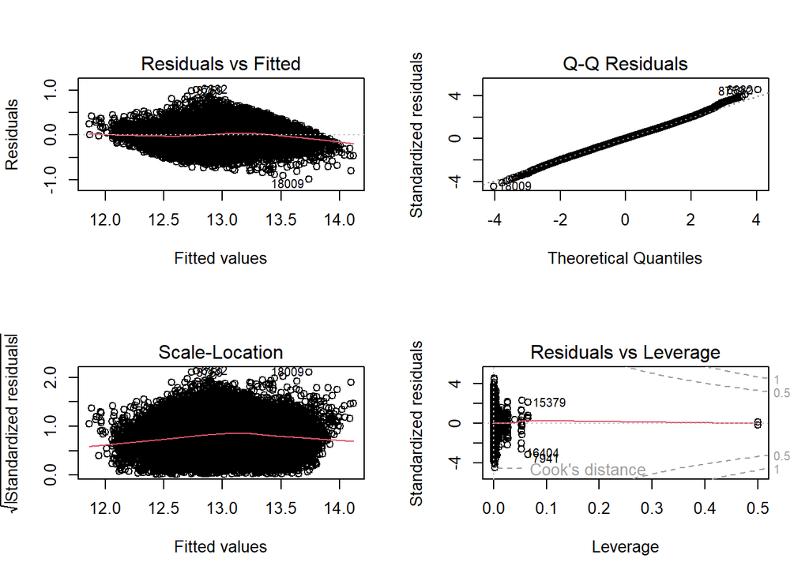

```r
# Plot diagnostic plots for model_refined
par(mfrow = c(2, 2))  # Set up a 2x2 grid for plots
plot(model_refined2)
```

### Final Model Equation and Interpretation

The final selected model predicts the log-transformed price of houses ($\log(\text{price})$) based on 21 predictors and an intercept.

```r
#Summary of selected Model
summary(model_refined2)
```

```
##
## Call:
## lm(formula = log_price ~ lat + sqft_living + yr_built + bedrooms +
##     sqft_living15 + floors + grade + view + year_sold + bathrooms +
##     waterfront, data = refined_data)
##
## Residuals:
##      Min       1Q   Median       3Q      Max
## -0.98641 -0.14650  0.00176  0.14521  1.00715
##
## Coefficients:
##                 Estimate Std. Error t value Pr(>|t|)
## (Intercept)   -1.274e+02  6.977e+00 -18.257  < 2e-16 ***
## lat            1.277e+00  1.195e-02 106.892  < 2e-16 ***
## sqft_living    1.419e-04  4.451e-06  31.892  < 2e-16 ***
## yr_built      -3.805e-03  7.601e-05 -50.053  < 2e-16 ***
## bedrooms      -1.740e-02  2.426e-03  -7.172 7.69e-13 ***
## sqft_living15  1.018e-04  4.375e-06  23.265  < 2e-16 ***
## floors         5.395e-02  3.361e-03  16.051  < 2e-16 ***
## grade4         1.905e-01  2.709e-01   0.703 0.481915
## grade5         2.626e-01  2.224e-01   1.181 0.237686
## grade6         4.818e-01  2.213e-01   2.177 0.029506 *
## grade7         6.653e-01  2.213e-01   3.006 0.002648 **
## grade8         8.253e-01  2.214e-01   3.729 0.000193 ***
## grade9         9.689e-01  2.214e-01   4.376 1.22e-05 ***
## grade10        1.026e+00  2.216e-01   4.628 3.72e-06 ***
## grade11        1.045e+00  2.231e-01   4.684 2.84e-06 ***
## view1          1.030e-01  1.506e-02   6.838 8.29e-12 ***
## view2          9.660e-02  8.832e-03  10.938  < 2e-16 ***
## view3          9.395e-02  1.451e-02   6.473 9.83e-11 ***
## view4          2.211e-01  3.551e-02   6.226 4.89e-10 ***
## year_sold      4.257e-02  3.445e-03  12.358  < 2e-16 ***
## bathrooms      4.731e-02  3.173e-03  14.910  < 2e-16 ***
## waterfront1    1.647e-01  5.562e-02   2.961 0.003075 **
## ---
## Signif. codes:  0 '***' 0.001 '**' 0.01 '*' 0.05 '.' 0.1 ' ' 1
##
## Residual standard error: 0.2212 on 18972 degrees of freedom
## Multiple R-squared:  0.7071, Adjusted R-squared:  0.7068
## F-statistic:  2181 on 21 and 18972 DF,  p-value: < 2.2e-16
```

The equation is as follows:

$$\log(\text{price}) = \beta_0 + \beta_1 \cdot \text{lat} + \beta_2 \cdot
\text{sqft_living} + \beta_3 \cdot \text{yr_built} +
\beta_4 \cdot \text{bedrooms} + \beta_5 \cdot \text{sqft_living15} +
\beta_6 \cdot \text{floors} +\\
\beta_7 \cdot \text{grade4} + \beta_8 \cdot \text{grade5} + \beta_9
\cdot \text{grade6} +
\beta_{10} \cdot \text{grade7} + \beta_{11} \cdot \text{grade8} +
\beta_{12} \cdot \text{grade9} +
\beta_{13} \cdot \text{grade10} + \\ \beta_{14} \cdot \text{grade11} +
\beta_{15} \cdot \text{view1} + \beta_{16} \cdot \text{view2} +
\beta_{17} \cdot \text{view3} +
\beta_{18} \cdot \text{view4} + \beta_{19} \cdot \text{year_sold} + \\
\beta_{20} \cdot \text{bathrooms} + \beta_{21} \cdot \text{waterfront1}
+ \epsilon$$

### Model Interpretation

- **Intercept ($\beta_0$):**

The base $\log(\text{price})$ when all predictors are at their reference levels, though this is not meaningful in practical terms.

- **Latitude ($\beta_1 = 1.277$):**

A one-unit increase in latitude corresponds to a 1.277 increase in $\log(\text{price})$, holding other variables constant.

- **Square Footage ($\beta_2 = 0.0001419$):**

For every additional square foot of living space, $\log(\text{price})$ increases by 0.0001419.

- **Bedrooms ($\beta_4 = -0.0174$):**

Each additional bedroom decreases $\log(\text{price})$ by 0.0174, likely due to reduced room sizes.

- **Other Predictors:**
  - **Floors ($\beta_6 = 0.05395$)**:

  Additional floors increase $\log(\text{price})$.
  - **Grade Levels ($\beta_7$ to $\beta_{14}$)**:

  Higher grades significantly increase $\log(\text{price})$, with the largest impact from grade 11.
  - **View Levels ($\beta_{15}$ to $\beta_{18}$)**:

  Better views positively affect $\log(\text{price})$, with the strongest effect from view4.
  - **Year Sold ($\beta_{19} = 0.04257$):**

  Later sales increase $\log(\text{price})$.
  - **Bathrooms ($\beta_{20} = 0.04731$)**:

  Each additional bathroom increases $\log(\text{price})$.
  - **Waterfront ($\beta_{21} = 0.1647$):**

  Waterfront properties command a higher $\log(\text{price})$.

### Diagnostic Plots for Refined Model Without Condition

The diagnostic plots above evaluate the assumptions of the refined model without the `condition` predictor.

- **Residuals vs Fitted**: This plot shows residuals scattered around zero with a slight curvature, suggesting minor non-linearity in the relationship between predictors and the response variable.
- **Q-Q Plot**: The majority of residuals align with the diagonal line, indicating approximate normality, though deviations at the tails point to potential outliers or non-normality in extreme values.
- **Scale-Location Plot**: The relatively flat red line and consistent spread of residuals suggest constant variance (homoscedasticity), with minimal heteroscedasticity.
- **Residuals vs Leverage**: This plot highlights influential points that have high leverage and may disproportionately affect the model’s fit, as indicated by Cook’s distance.

### Model Selection and Recommendations

Based on the analysis, we have chosen the refined model without the `condition` predictor as our final model. This model balances explanatory power and simplicity, achieving a relatively high $R^2$ (0.7071) and Adjusted $R^2$ (0.7068) while minimizing SSE and maintaining favorable AIC and BIC scores. Future refinements could include exploring robust regression techniques or machine learning techniques. The chosen model provides a strong foundation for predicting house prices and delivering actionable insights.

### Reflection

This project provided valuable insights into the factors influencing house prices and the importance of rigorous model selection. A deeper understanding of the multiple regression analysis studied during the semester was enhanced through practical application. It was great to see these concepts reinforced while working on the project, bridging theoretical knowledge with real-world data analysis.